# Self-Driving Car Engineer Nanodegree

## Project: Build a Traffic Sign Recognition Classifier

In this notebook, a template is provided for you to implement your functionality in stages which is required to successfully complete this project. If additional code is required that cannot be included in the notebook, be sure that the Python code is successfully imported and included in your submission, if necessary. Sections that begin with **'Implementation'** in the header indicate where you should begin your implementation for your project. Note that some sections of implementation are optional, and will be marked with **'Optional'** in the header.

In addition to implementing code, there will be questions that you must answer which relate to the project and your implementation. Each section where you will answer a question is preceded by a **'Question'** header. Carefully read each question and provide thorough answers in the following text boxes that begin with **'Answer:'**. Your project submission will be evaluated based on your answers to each of the questions and the implementation you provide.

> **Note:** Code and Markdown cells can be executed using the **Shift + Enter** keyboard shortcut. In addition, Markdown cells can be edited by typically double-clicking the cell to enter edit mode.

## Step 0: Load The Data

```python
# Load pickled data
import pickle

# TODO: Fill this in based on where you saved the training and testing data

training_file = 'train.p'
testing_file = 'test.p'

with open(training_file, mode='rb') as f:
    train = pickle.load(f)
with open(testing_file, mode='rb') as f:
    test = pickle.load(f)

X_train, y_train = train['features'], train['labels']
X_test, y_test = test['features'], test['labels']
```

```python
#carve out a validattion set from the train set
import numpy as np

np.random.RandomState(42)
idx = np.random.permutation(range(len(y_train)))

p=int(.1*len(y_train))
X_valid = X_train[idx[:p]]
y_valid = y_train[idx[:p]]
X_train = X_train[idx[p:]]
y_train = y_train[idx[p:]]
print('valid', len(y_valid))
print('train', len(y_train))
print('test', len(y_test))
```

```
valid 3920
train 35289
test 12630
```

## Step 0.5 Load the sign names xref

```python
#load xref for sign names
with open('signnames.csv', 'rb') as f:
    sign_names_data = str(f.read())

#would normally use pandas or csv module but figured this would be fine for the small file size
ID_TO_NAME = dict( (int(v[0]),v[1]) for v in map(lambda x: x.split(','), sign_names_data.split('\\n')) if len(v)>1 and v[0].isdigit())
del sign_names_data
```

## Step 1: Dataset Summary & Exploration

The pickled data is a dictionary with 4 key/value pairs:

- `'features'` is a 4D array containing raw pixel data of the traffic sign images, (num examples, width, height, channels).
- `'labels'` is a 2D array containing the label/class id of the traffic sign. The file `signnames.csv` contains id -> name mappings for each id.
- `'sizes'` is a list containing tuples, (width, height) representing the the original width and height the image.
- `'coords'` is a list containing tuples, (x1, y1, x2, y2) representing coordinates of a bounding box around the sign in the image. **THESE COORDINATES ASSUME THE ORIGINAL IMAGE. THE PICKLED DATA CONTAINS RESIZED VERSIONS (32 by 32) OF THESE IMAGES**

Complete the basic data summary below.

```python
### Replace each question mark with the appropriate value.

# TODO: Number of training examples
n_train = X_train.shape[0]

# TODO: Number of testing examples.
n_test = X_test.shape[0]

# TODO: What's the shape of an traffic sign image?
image_shape = X_train.shape[1:]

# TODO: How many unique classes/labels there are in the dataset.
n_classes = len( set(y_train) | set(y_test) )

print("Number of training examples =", n_train)
print("Number of testing examples =", n_test)
print("Image data shape =", image_shape)
print("Number of classes =", n_classes)
```

```
Number of training examples = 35289
Number of testing examples = 12630
Image data shape = (32, 32, 3)
Number of classes = 43
```

Visualize the German Traffic Signs Dataset using the pickled file(s). This is open ended, suggestions include: plotting traffic sign images, plotting the count of each sign, etc.

The [Matplotlib](http://matplotlib.org/) [examples](http://matplotlib.org/examples/index.html) and [gallery](http://matplotlib.org/gallery.html) pages are a great resource for doing visualizations in Python.

**NOTE:** It's recommended you start with something simple first. If you wish to do more, come back to it after you've completed the rest of the sections.

```python
### Data exploration visualization goes here.
### Feel free to use as many code cells as needed.
import matplotlib.patches as patches
import matplotlib.pyplot as plt
import seaborn as sn
import numpy as np


def bounding_box(org_size,box):
    '''convert the bounding box to image units'''
    #original size
    w,h= org_size
    #our current is size (32,32)
    w_scale = 32.0/w
    h_scale = 32.0/h
    x1,y1,x2,y2 = box
    return [x1*w_scale,y1*h_scale,x2*w_scale,y2*h_scale]

def draw_bounding_box(box, ax):
    '''draw the bounding box'''
    x1,y1,x2,y2 = box
    w=x2-x1
    h=y2-y1

    ax.add_patch(
        patches.Rectangle(
            (x1, y1),
            w,
            h,
            fill=False,      # remove background
            edgecolor = '#00ff00'
        )
    )

def plot_random_train_sign_sample(N):
    idx = np.random.permutation(range(len(X_train)))[:N]

    w=5
    off =0
    if N%5 !=0:
        off = 1

    h = N/5 +off

    fig = plt.figure(figsize=(w*2.5,h*2.5*.7))

    for j,i in enumerate(idx):
        plt.subplot(h ,w,j+1)

        x0=X_train[i]
        plt.imshow(x0)
        plt.title(ID_TO_NAME[y_train[i]])


        ax = plt.gca()
        try:
            box=bounding_box(train['sizes'][i],train['coords'][i])
            draw_bounding_box(box,plt.gca())
        except:
            pass

        ax.get_xaxis().set_visible(False)
        ax.get_yaxis().set_visible(False)

    plt.tight_layout(pad=0.0)
```

```python
sn.set_style("whitegrid", {'axes.grid' : False})

%matplotlib inline
```

```python
from scipy.ndimage.interpolation import zoom, rotate, shift

def zoom_clip(img, zoom_factor):
    zoomed = zoom(img,(zoom_factor,zoom_factor,1), mode='nearest',order=1)
    offset=int( (zoomed.shape[0] - 32)/2)
    zoomed = zoomed[offset:offset+32,offset:offset+32]
    return zoomed

def generate_image(i,MAX_ROTATE=15, MAX_SHIFT=4):
    img=X_train[i]
    box = bounding_box(train['sizes'][i],train['coords'][i])

    #shift the image, we first calculate the maximum amount we can shift in any direction
    xr,xl = int(box[0]),int(32-box[2])
    yt,yb = int(box[1]),int(32-box[3])

    xr=min(xr,MAX_SHIFT)
    xl=min(xr,MAX_SHIFT)
    yt=min(xr,MAX_SHIFT)
    yb=min(xr,MAX_SHIFT)

    y_shift=np.random.choice(np.arange(-yt,yb,1)) if yt+yb !=0 else 0
    x_shift=np.random.choice(np.arange(-xr,xl,1)) if xr+xl !=0 else 0
    box[0]+=x_shift
    box[2]+=x_shift
    box[1]+=y_shift
    box[3]+=y_shift

    img=shift(X_train[i],[y_shift,x_shift,0],mode='nearest')

    #maybe rotate
    rot_angle = 2*(np.random.rand()-.5)*MAX_ROTATE
    img=rotate(img,rot_angle,reshape=False,mode='nearest')

    #maybe zoom?
    max_offset = 2*min([box[0],box[1],32-box[2],32-box[3]])
    max_zoom = (max_offset+32) / 32

    zoom_factor =  1+np.random.rand()*(max_zoom-1)
    img=zoom_clip(img,zoom_factor)

    return img
```

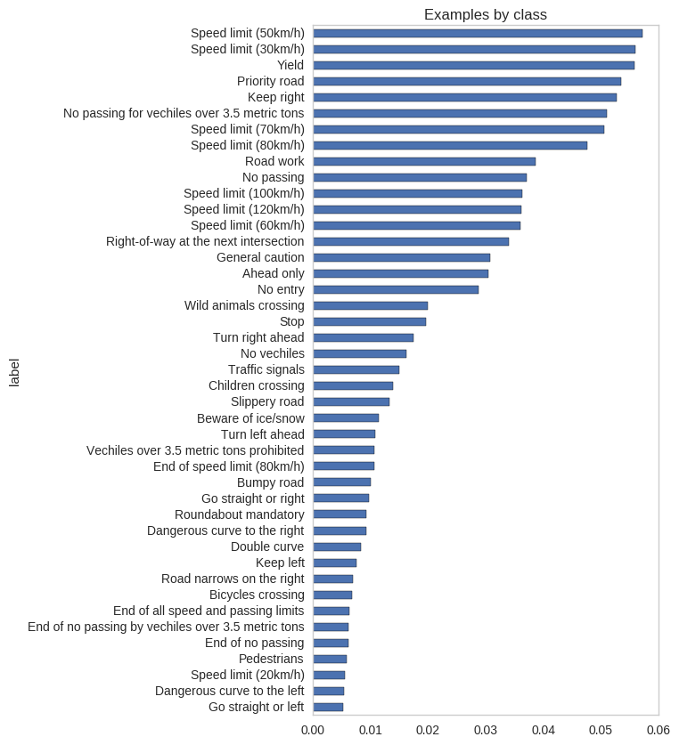

```python
import pandas as pd

#check the lable balance
ids, qty = np.unique(y_train, return_counts=True)

df = pd.DataFrame(list(zip(ids,qty)), columns=['id','qty'])
df['label']=df.id.apply(lambda x: ID_TO_NAME[x])
df['p']=df.qty/df.qty.sum()

fig=plt.figure(figsize=(5,10))
df.set_index('label').sort_values('p').p.plot(kind='barh', ax=plt.gca())
plt.title('Examples by class')
```

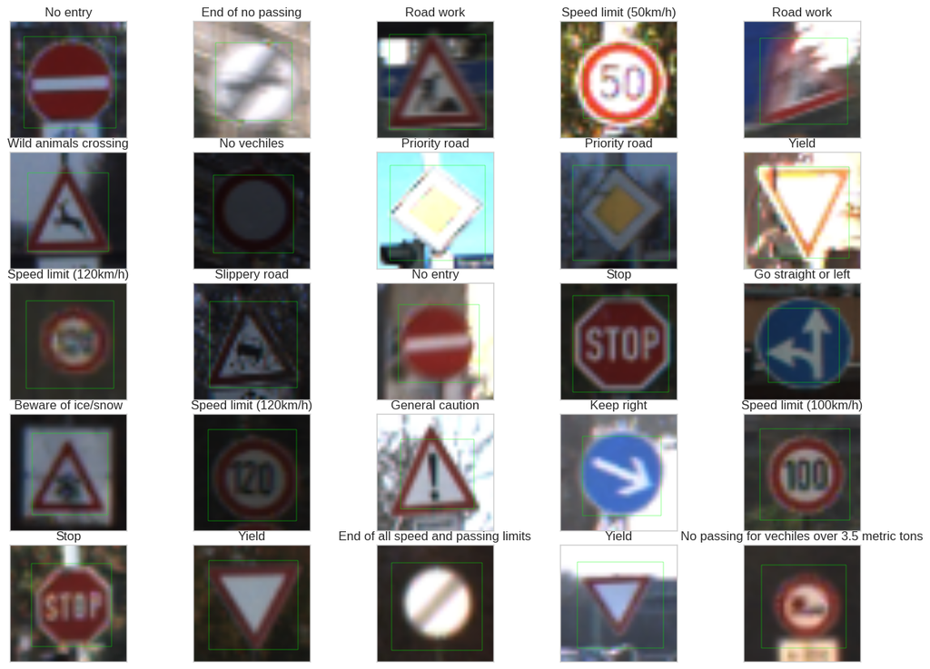

```python
plot_random_train_sign_sample(25)
```

## Generate some fake data

```python
training_file = 'train.p'
testing_file = 'test.p'

with open(training_file, mode='rb') as f:
    train = pickle.load(f)
with open(testing_file, mode='rb') as f:
    test = pickle.load(f)
```

```python
def maybe_generate(NUM_PER_CAT=3000):
    '''load the images if we already generated them, or generate them'''

    try:
        with open('new_x.p', mode='rb') as f:
            new_x = pickle.load(f)
        with open('new_y.p', mode='rb') as f:
            new_y = pickle.load(f)

        print('images loaded from file')
        return new_x, new_y
    except Exception as e:
        print(e)
        print('could not load, generating now')

    #split the images into to categories by their label id
    cats=dict([i,[]] for i in set(y_train))

    for i in range(len(y_train)):
        cats[y_train[i]].append(i)

    np.random.RandomState(42)

    new_x = []
    new_y=[]

    for k in cats:
        N = NUM_PER_CAT - len(cats[k])
        print(ID_TO_NAME[k],N)
        for _ in range(N):
            i = np.random.choice(cats[k])
            img = generate_image(i)
            if img.shape ==(32,32,3):
                new_x.append(img)
                new_y.append(k)

    print('generated {} new images'.format(len(new_y)))

    pickle.dump( new_x, open( "new_x.p", "wb" ) )
    pickle.dump( new_y, open( "new_y.p", "wb" ) )

    return new_x, new_y
```

```python
%%time

new_x, new_y = maybe_generate()
```

```
images loaded from file
CPU times: user 294 ms, sys: 120 ms, total: 415 ms
Wall time: 391 ms
```

```python
y_train = np.concatenate([y_train,new_y])
X_train = np.concatenate([X_train,np.concatenate(new_x).reshape([len(new_y),32,32,3])])
del new_y
del new_x
```

## Step 2: Design and Test a Model Architecture

Design and implement a deep learning model that learns to recognize traffic signs. Train and test your model on the [German Traffic Sign Dataset](http://benchmark.ini.rub.de/?section=gtsrb&subsection=dataset).

There are various aspects to consider when thinking about this problem:

- Neural network architecture
- Play around preprocessing techniques (normalization, rgb to grayscale, etc)
- Number of examples per label (some have more than others).
- Generate fake data.

Here is an example of a [published baseline model on this problem](http://yann.lecun.com/exdb/publis/pdf/sermanet-ijcnn-11.pdf). It's not required to be familiar with the approach used in the paper but, it's good practice to try to read papers like these.

**NOTE:** The LeNet-5 implementation shown in the classroom at the end of the CNN lesson is a solid starting point. You'll have to change the number of classes and possibly the preprocessing, but aside from that it's plug and play!

```python
import tensorflow as tf
from tensorflow.contrib.layers import flatten
```

```python
tf.reset_default_graph()

x = tf.placeholder(tf.float32, (None, 32, 32, 3),name='x')
y = tf.placeholder(tf.int32, (None),name='y')
one_hot_y = tf.one_hot(y, n_classes)
```

```python
def conv_max_pool_layer(x, conv_shape, name,conv_strides=[1,1,1,1],max_pool_strides=[1,2,2,1],ksize=[1,2,2,1], padding='SAME', mu=0,sigma=.1):
    '''a conv2d layer with a max pool layer, returns weights, bias, and result of the operations'''
    #weights
    w = tf.Variable(tf.truncated_normal(conv_shape, mean=mu, stddev=sigma), name='w_%s'%name)
    #bias
    b = tf.Variable(tf.zeros(conv_shape[-1]), name='b_%s'%name)
    #convolution with relu
    c = tf.nn.relu(tf.nn.conv2d(x,w, strides=conv_strides, padding=padding)+b)
    #max pool it up
    c = tf.nn.max_pool(c,ksize=ksize,strides=max_pool_strides, padding=padding)

    return w,b,c


def model(x):

    tf.set_random_seed(42)

    mu=0
    sigma=.1

    n1= 32
    n2= 64
    n3= 128

    #input (?,32,32,3) #output (?,16,16,n1)
    cw1, cb1, c1 = conv_max_pool_layer(x,[5,5,3,n1], 'c1',mu=mu, sigma=sigma)
    cw2, cb2, c2 = conv_max_pool_layer(c1,[5,5,n1,n2], 'c2', mu=mu, sigma=sigma)
    cw3, cb3, c3 = conv_max_pool_layer(c2,[5,5,n2,n3], 'c3',mu=mu, sigma=sigma)


    #flat
    flat = flatten(c3)
    #print(c3.get_shape())

    #fully connected
    hidden_size = 256
    fw1 = tf.Variable(tf.truncated_normal([4*4*n3,hidden_size], mean=mu, stddev=sigma), name='fw1')
    fb1 = tf.Variable(tf.zeros(hidden_size), name='fb1')

    h1 = tf.nn.relu( tf.matmul(flat,fw1)+fb1 )

    #second fully connected layer
    fw2 = tf.Variable(tf.truncated_normal([hidden_size,hidden_size], mean=mu, stddev=sigma), name='fw2')
    fb2 = tf.Variable(tf.zeros(hidden_size), name='fb2')

    h2 = tf.nn.relu( tf.matmul(h1,fw2)+fb2 )

    #third fully connected layer
    fw3 = tf.Variable(tf.truncated_normal([hidden_size,n_classes], mean=mu, stddev=sigma), name='fw3')
    fb3 = tf.Variable(tf.zeros(n_classes), name='fb3')

    #logits
    h3 = tf.matmul(h2,fw3)+fb3

    #return the l2 norm for the convolution weights and the fully connected weights
    l2_loss = sum(map(lambda z: tf.nn.l2_loss(z), [cw1,cw2,cw3,fw1,fw2,fw3]))

    return h3, l2_loss
```

```python
beta = 1e-3
logits,l2_loss = model(x)
loss_operation = tf.reduce_mean(tf.nn.softmax_cross_entropy_with_logits(logits, one_hot_y))+beta*l2_loss
optimizer = tf.train.AdamOptimizer()
training_operation = optimizer.minimize(loss_operation)
correct_prediction = tf.equal(tf.argmax(logits, 1), tf.argmax(one_hot_y, 1))
accuracy_operation = tf.reduce_mean(tf.cast(correct_prediction, tf.float32))
```

```python
%%time

np.random.RandomState(42)

idx = np.random.permutation(len(y_train))
X_train= X_train[idx]
y_train = y_train[idx]

BATCH_SIZE=128
NUM_EPOCHS=40
EPOCH_SIZE = int(len(X_train)/BATCH_SIZE)

saver = tf.train.Saver()

with tf.Session() as sess:
    sess.run(tf.global_variables_initializer())

    feed_dict={}
    for epoch in range(NUM_EPOCHS):
        for i in range(EPOCH_SIZE):
            #sample_idx = np.random.permutation(len(y_train))[:BATCH_SIZE]
            #feed_dict = {x:X_train[sample_idx],y:y_train[sample_idx]}
            feed_dict={x:X_train[i*BATCH_SIZE:(i+1)*BATCH_SIZE]
                      ,y:y_train[i*BATCH_SIZE:(i+1)*BATCH_SIZE]}
            _ = sess.run([training_operation], feed_dict=feed_dict)

        #get the loss and accuracy on our last batch
        loss, acc = sess.run([loss_operation,accuracy_operation], feed_dict=feed_dict)
        #get accuracy on the test set
        accuracy =  sess.run([accuracy_operation], feed_dict={x:X_test, y:y_test})
        print('epoch: {}\tloss: {:.5f}\ttrain_acc: {:.3f}\ttest_acc {:.3f}'.format(epoch,loss,acc,accuracy[0]))

    save_path = saver.save(sess, "models/model.ckpt")
    print("Model saved in file: %s" % save_path)
```

```
epoch: 0	loss: 5.66808	train_acc: 0.234	test_acc 0.178
epoch: 1	loss: 4.64098	train_acc: 0.414	test_acc 0.332
epoch: 2	loss: 3.61191	train_acc: 0.625	test_acc 0.565
epoch: 3	loss: 2.95562	train_acc: 0.781	test_acc 0.655
epoch: 4	loss: 2.51663	train_acc: 0.852	test_acc 0.722
epoch: 5	loss: 2.17212	train_acc: 0.883	test_acc 0.781
epoch: 6	loss: 1.89783	train_acc: 0.875	test_acc 0.816
epoch: 7	loss: 1.49114	train_acc: 0.938	test_acc 0.864
epoch: 8	loss: 1.24133	train_acc: 0.938	test_acc 0.866
epoch: 9	loss: 0.94049	train_acc: 0.969	test_acc 0.884
epoch: 10	loss: 0.67721	train_acc: 0.984	test_acc 0.890
epoch: 11	loss: 0.46661	train_acc: 0.992	test_acc 0.918
epoch: 12	loss: 0.37524	train_acc: 0.992	test_acc 0.906
epoch: 13	loss: 0.27118	train_acc: 1.000	test_acc 0.915
epoch: 14	loss: 0.23736	train_acc: 1.000	test_acc 0.922
epoch: 15	loss: 0.24157	train_acc: 0.984	test_acc 0.914
epoch: 16	loss: 0.22912	train_acc: 0.992	test_acc 0.932
epoch: 17	loss: 0.19494	train_acc: 0.992	test_acc 0.943
epoch: 18	loss: 0.17919	train_acc: 1.000	test_acc 0.942
epoch: 19	loss: 0.17754	train_acc: 0.992	test_acc 0.940
epoch: 20	loss: 0.18709	train_acc: 0.992	test_acc 0.933
epoch: 21	loss: 0.16045	train_acc: 1.000	test_acc 0.933
epoch: 22	loss: 0.19244	train_acc: 0.992	test_acc 0.934
epoch: 23	loss: 0.19657	train_acc: 0.984	test_acc 0.930
epoch: 24	loss: 0.17246	train_acc: 1.000	test_acc 0.908
epoch: 25	loss: 0.15568	train_acc: 1.000	test_acc 0.934
epoch: 26	loss: 0.15590	train_acc: 1.000	test_acc 0.948
epoch: 27	loss: 0.15125	train_acc: 0.992	test_acc 0.953
epoch: 28	loss: 0.15558	train_acc: 0.992	test_acc 0.946
epoch: 29	loss: 0.14217	train_acc: 1.000	test_acc 0.957
epoch: 30	loss: 0.14181	train_acc: 1.000	test_acc 0.959
epoch: 31	loss: 0.14454	train_acc: 1.000	test_acc 0.944
epoch: 32	loss: 0.14250	train_acc: 0.992	test_acc 0.954
epoch: 33	loss: 0.15380	train_acc: 0.992	test_acc 0.959
epoch: 34	loss: 0.13339	train_acc: 1.000	test_acc 0.951
epoch: 35	loss: 0.13270	train_acc: 1.000	test_acc 0.954
epoch: 36	loss: 0.13057	train_acc: 1.000	test_acc 0.943
epoch: 37	loss: 0.14151	train_acc: 1.000	test_acc 0.963
epoch: 38	loss: 0.13746	train_acc: 1.000	test_acc 0.955
epoch: 39	loss: 0.12766	train_acc: 1.000	test_acc 0.955
Model saved in file: models/model.ckpt
CPU times: user 6min 36s, sys: 0 ns, total: 6min 36s
Wall time: 6min 44s
```

### Implementation

Use the code cell (or multiple code cells, if necessary) to implement the first step of your project. Once you have completed your implementation and are satisfied with the results, be sure to thoroughly answer the questions that follow.

### Question 1

*Describe how you preprocessed the data. Why did you choose that technique?*

**Answer:**

I did not do any preprocessing. I thought about normalizing both the colors and sizes, but I wanted the network to be robust to having off center images and while a stop sign is red, the color recorded is influenced by lighting conditions so I opted to leave everything alone.

### Question 2

*Describe how you set up the training, validation and testing data for your model. **Optional**: If you generated additional data, how did you generate the data? Why did you generate the data? What are the differences in the new dataset (with generated data) from the original dataset?*

**Answer:**

The training and testing sets were loaded from the pickle so I did not modify that split. I carved out random sample roughly 10% of the supplied training data prior to generating fake data.

I generated a lot of fake data, in fact most of my training data was fake. I first wanted to balance the classes in the training data, so I needed to generate. Secondly I wanted the network to be somewhat translation and rotation invariant so I shifted, zoomed, and rotated data. I thought about mirroring, skewing, and adjusting color values as well but ultimately did not implement.

On the small validation set I achieved 99.4% accuracy

### Question 3

*What does your final architecture look like? (Type of model, layers, sizes, connectivity, etc.) For reference on how to build a deep neural network using TensorFlow, see Deep Neural Network in TensorFlow from the classroom.*

**Answer:**

I utilized three convolutional layers each with a max pool operation. layer 1. 5x5 with 32 convolutions layer 2. 5x5 with 64 layer 3. 5x5 with 128

I then flattened all the features out and ran them through a three layer feed forward network. I utilized relu for activation and had a hidden layer size of 256.

### Question 4

*How did you train your model? (Type of optimizer, batch size, epochs, hyperparameters, etc.)*

### Question 5

*What approach did you take in coming up with a solution to this problem? It may have been a process of trial and error, in which case, outline the steps you took to get to the final solution and why you chose those steps. Perhaps your solution involved an already well known implementation or architecture. In this case, discuss why you think this is suitable for the current problem.*

**Answer:**

The process was largely trial and error. I initially made the network large (added layer and increased layer size) enough to perform well on the training set but poorly on the test set. At that time I had not generated any fake data so I could easily check the loss and accuracy on the entire training set quickly. Once the network was big enough to perform well on the training set but poorly on the test set I switched to making fake data. After introducing some shifts and rotations in my data I found increasing the number of convolutions helped. Finally, I added the L2 regularization. Finally after everything was done I ran the model on the validation set.

## Step 3: Test a Model on New Images

Take several pictures of traffic signs that you find on the web or around you (at least five), and run them through your classifier on your computer to produce example results. The classifier might not recognize some local signs but it could prove interesting nonetheless.

You may find `signnames.csv` useful as it contains mappings from the class id (integer) to the actual sign name.

### Implementation

Use the code cell (or multiple code cells, if necessary) to implement the first step of your project. Once you have completed your implementation and are satisfied with the results, be sure to thoroughly answer the questions that follow.

```python
def classify_set(X):
    tf.reset_default_graph()

    x = tf.placeholder(tf.float32, (None, 32, 32, 3), name='x')
    #y = tf.placeholder(tf.int32, (None), name='y')
    #one_hot_y = tf.one_hot(y, n_classes)

    logits,l2_loss = model(x)

    probs = tf.nn.softmax(logits)
    top5 = tf.nn.top_k(probs, k=5)
    #correct_prediction = tf.equal(tf.argmax(logits, 1), tf.argmax(one_hot_y, 1))
    #accuracy_operation = tf.reduce_mean(tf.cast(correct_prediction, tf.float32))

    with tf.Session() as sess:


        #sess.run(tf.global_variables_initializer())
        saver = tf.train.Saver()
        saver.restore(sess,'models/model.ckpt')

        #print("Model restored.")
        #acc = sess.run(accuracy_operation, feed_dict={x:X_valid, y:y_valid})
        #print('on valid set: ', acc)

        top5_pred = sess.run(top5, feed_dict={x:X})

    return top5_pred[0], top5_pred[1]
```

```python
#load our images (processed and resized in other notebook due to weird namespace conflict)
with open('test_images.p', mode='rb') as f:
    new_images = pickle.load(f)
```

```python
new_images = np.reshape(new_images,(-1,32,32,3))
```

```python
probs, class_idx = classify_set(new_images)
class_names = [ [ID_TO_NAME[c] for c in row] for row in class_idx]
```

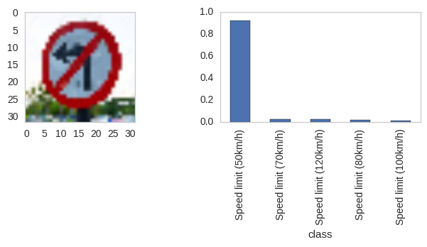

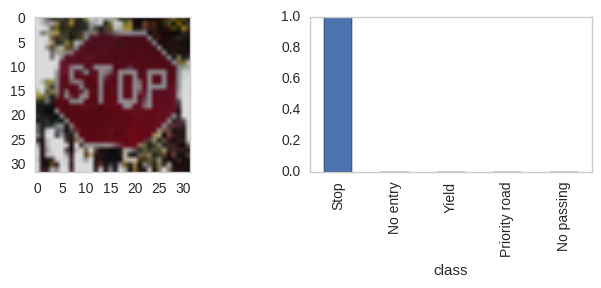

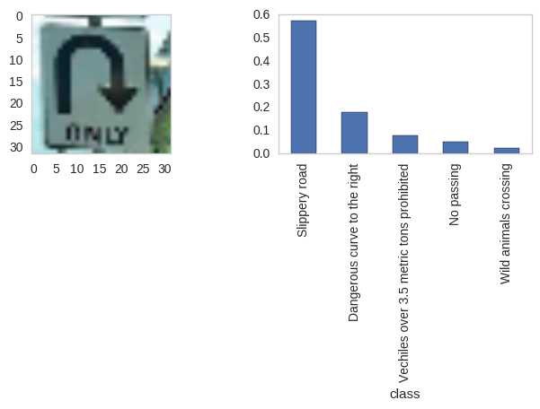

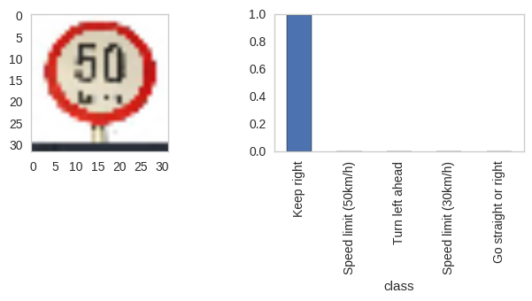

[figure not shown]

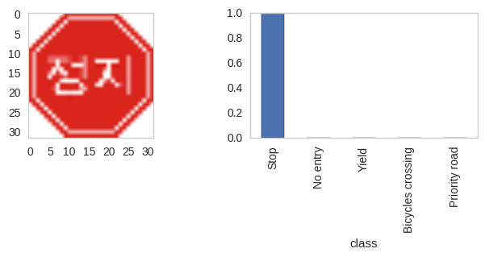

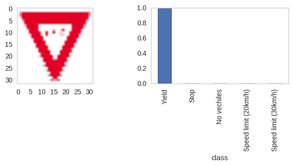

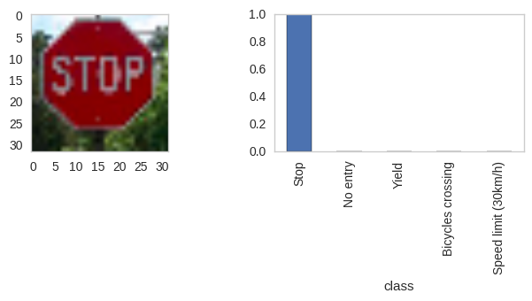

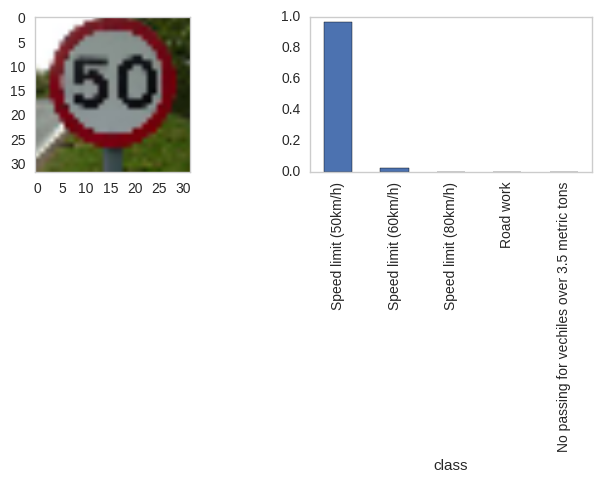

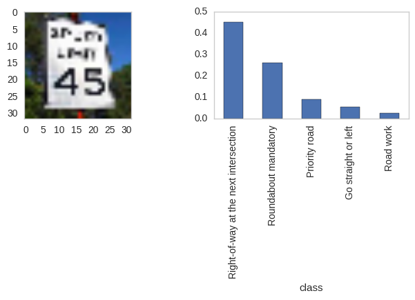

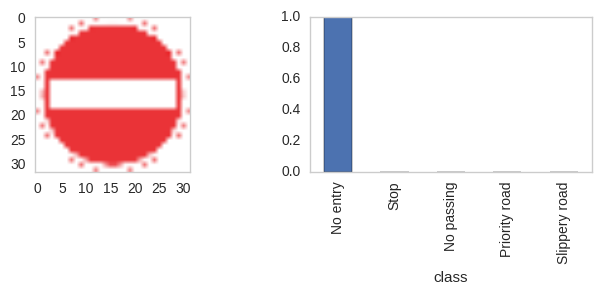

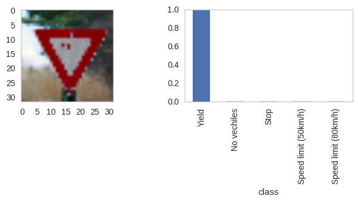

[1 more figures not shown]

```python
for im, ps, cnames in zip(new_images,probs,class_names):
    plt.figure(figsize=(8,2))
    plt.subplot(1,2,1)
    plt.imshow(im)
    plt.subplot(1,2,2)
    pd.DataFrame({'ps':ps,'class':cnames}).set_index('class').plot(kind='bar', ax=plt.gca(),legend=False,title=None)
```

### Question 6

*Choose five candidate images of traffic signs and provide them in the report. Are there any particular qualities of the image(s) that might make classification difficult? It could be helpful to plot the images in the notebook.*

**Answer:**

Some had fine details and after resizing even I could not make them out. Others are of signs that are not in the train set because they are not german. I also included a fictitious stop sign in the style of a pokeball. I thought the network might get it right due to its hexagonal shape but unfortunately it did not.

```python
#7 of 13 images were classfied correctly.
print( 'accuracy on random internet images:',7./13 )
```

```
accuracy on random internet images: 0.5384615384615384
```

### Question 7

*Is your model able to perform equally well on captured pictures when compared to testing on the dataset? The simplest way to do this check the accuracy of the predictions. For example, if the model predicted 1 out of 5 signs correctly, it's 20% accurate.*

**NOTE:** You could check the accuracy manually by using `signnames.csv` (same directory). This file has a mapping from the class id (0-42) to the corresponding sign name. So, you could take the class id the model outputs, lookup the name in `signnames.csv` and see if it matches the sign from the image.

**Answer:**

7 of the 13 images I used were classified correctly, 54% accuracy.

### Question 8

*Use the model's softmax probabilities to visualize the **certainty** of its predictions, [`tf.nn.top_k`](https://www.tensorflow.org/versions/r0.12/api_docs/python/nn.html#top_k) could prove helpful here. Which predictions is the model certain of? Uncertain? If the model was incorrect in its initial prediction, does the correct prediction appear in the top k? (k should be 5 at most)*

`tf.nn.top_k` will return the values and indices (class ids) of the top k predictions. So if k=3, for each sign, it'll return the 3 largest probabilities (out of a possible 43) and the correspoding class ids.

Take this numpy array as an example:

```
# (5, 6) array
a = np.array([[ 0.24879643,  0.07032244,  0.12641572,  0.34763842,  0.07893497,
         0.12789202],
       [ 0.28086119,  0.27569815,  0.08594638,  0.0178669 ,  0.18063401,
         0.15899337],
       [ 0.26076848,  0.23664738,  0.08020603,  0.07001922,  0.1134371 ,
         0.23892179],
       [ 0.11943333,  0.29198961,  0.02605103,  0.26234032,  0.1351348 ,
         0.16505091],
       [ 0.09561176,  0.34396535,  0.0643941 ,  0.16240774,  0.24206137,
         0.09155967]])
```

Running it through `sess.run(tf.nn.top_k(tf.constant(a), k=3))` produces:

```
TopKV2(values=array([[ 0.34763842,  0.24879643,  0.12789202],
       [ 0.28086119,  0.27569815,  0.18063401],
       [ 0.26076848,  0.23892179,  0.23664738],
       [ 0.29198961,  0.26234032,  0.16505091],
       [ 0.34396535,  0.24206137,  0.16240774]]), indices=array([[3, 0, 5],
       [0, 1, 4],
       [0, 5, 1],
       [1, 3, 5],
       [1, 4, 3]], dtype=int32))
```

Looking just at the first row we get `[ 0.34763842, 0.24879643, 0.12789202]`, you can confirm these are the 3 largest probabilities in `a`. You'll also notice `[3, 0, 5]` are the corresponding indices.

**Answer:**

See above for visualization of new images, below for random sample of the valid set

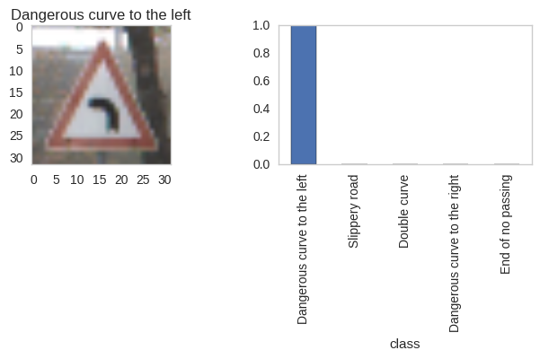

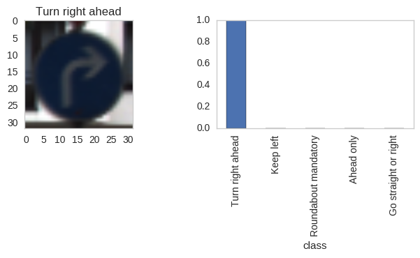

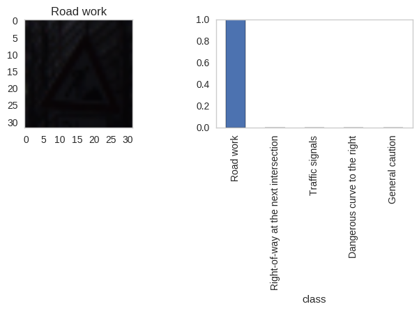

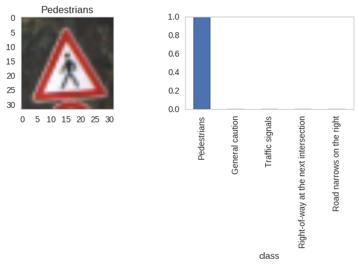

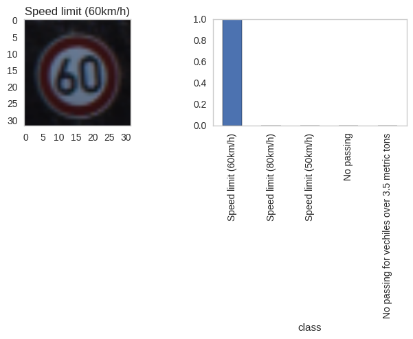

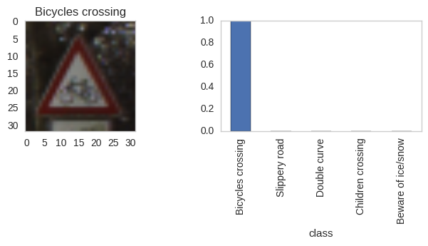

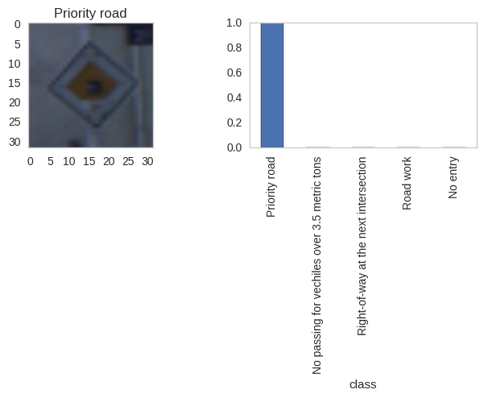

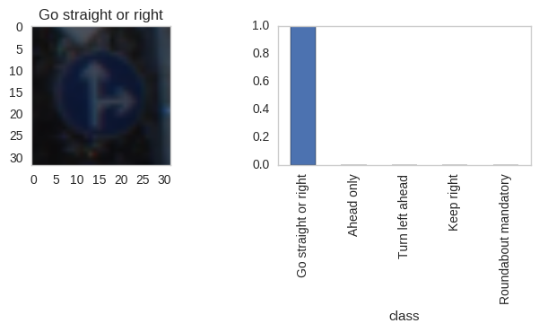

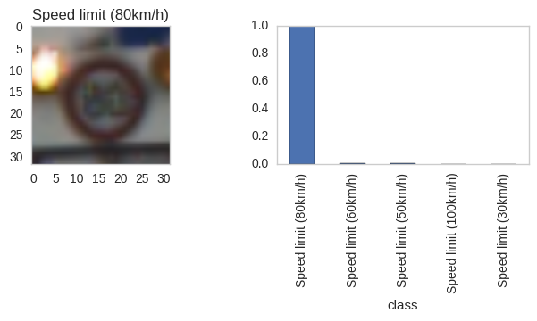

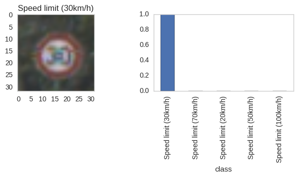

```python
idx=np.random.permutation(len(X_valid))[:10]

probs, class_idx = classify_set(X_valid[idx])
class_names = [ [ID_TO_NAME[c] for c in row] for row in class_idx]
actuals = [ ID_TO_NAME[c] for c in y_valid[idx]]

for im, ps, cnames, act in zip(X_valid[idx],probs,class_names, actuals):
    plt.figure(figsize=(8,2))
    plt.subplot(1,2,1)
    plt.imshow(im)
    plt.title(act)
    plt.subplot(1,2,2)
    pd.DataFrame({'ps':ps,'class':cnames}).set_index('class').plot(kind='bar', ax=plt.gca(),legend=False,title=None)
```

```python
tf.reset_default_graph()

x = tf.placeholder(tf.float32, (None, 32, 32, 3), name='x')
y = tf.placeholder(tf.int32, (None), name='y')
one_hot_y = tf.one_hot(y, n_classes)

logits,l2_loss = model(x)

correct_prediction = tf.equal(tf.argmax(logits, 1), tf.argmax(one_hot_y, 1))
accuracy_operation = tf.reduce_mean(tf.cast(correct_prediction, tf.float32))


with tf.Session() as sess:


    #sess.run(tf.global_variables_initializer())
    saver = tf.train.Saver()
    saver.restore(sess,'models/model.ckpt')

    print("Model restored.")
    acc = sess.run(accuracy_operation, feed_dict={x:X_valid, y:y_valid})
    print('acc on valid set: ', acc)
```

```
Model restored.
acc on valid set:  0.994898
```